# Data Munging

Version 2014-06-12

## 1. What Data Munging

- munging = mash until no good에서 파생된 단어
- 전처리, 파싱, 필터링과 같이 데이터를 핸들링 한다는 것을 뜻함
- 이와 동일한 작업을 할 수 있는 데이터 패키지로는 `data.table`, `sqldf`, `plyr` 패키지가 있음

## 2. 단정한 데이터 (tidy data)

- 데이터 전처리를 위해 패턴화한 데이터
- 단정한 데이터의 기준
  1. 각 변수의 개별 column(열)이 있다.
  2. 각 관측치는 row(행)을 구성한다.
  3. 각 테이블은 단 하나의 관측기준에 따라 조직된 데이터를 저장한다.
  4. 단정한 데이터를 만들기 위해 reshaping하여야 함

### 2-1. `melt()`

```r
load("D:/SDSEDU/munging/pew.RData")
head(raw, 5)
```

```
##             religion <$10k $10-20k $20-30k $30-40k $40-50k $50-75k
## 1           Agnostic    27      34      60      81      76     137
## 2            Atheist    12      27      37      52      35      70
## 3           Buddhist    27      21      30      34      33      58
## 4           Catholic   418     617     732     670     638    1116
## 5 Don't know/refused    15      14      15      11      10      35
##   $75-100k $100-150k >150k Don't know/refused
## 1      122       109    84                 96
## 2       73        59    74                 76
## 3       62        39    53                 54
## 4      949       792   633               1489
## 5       21        17    18                116
```

- 위의 자료는 '단정한 데이터'가 아님
- 수입(income)에 대해 세분화한 열을 제공함으로써, 단정한 데이터의 첫번째 기준을 위반했기 때문임
- 따라서 이 데이터를 '단정한 데이터'로 변환해 줄 필요가 있음

```r
library(reshape2)
melt.raw <- melt(raw, measure.vars = c(2, 3, 4, 5, 6, 7, 8, 9, 10, 11), variable = "income",
    value = "freq")
head(melt.raw, 10)
```

```
##                   religion income value
## 1                 Agnostic  <$10k    27
## 2                  Atheist  <$10k    12
## 3                 Buddhist  <$10k    27
## 4                 Catholic  <$10k   418
## 5       Don't know/refused  <$10k    15
## 6         Evangelical Prot  <$10k   575
## 7                    Hindu  <$10k     1
## 8  Historically Black Prot  <$10k   228
## 9        Jehovah's Witness  <$10k    20
## 10                  Jewish  <$10k    19
```

- melt() 함수를 사용하여 각 변수에 해당하는 column을 만듦으로써, 단정한 데이터가 된 것을 확인 할 수 있음

```r
data(french_fries)
head(french_fries, 3)
```

```
##    time treatment subject rep potato buttery grassy rancid painty
## 61    1         1       3   1    2.9     0.0      0    0.0    5.5
## 25    1         1       3   2   14.0     0.0      0    1.1    0.0
## 62    1         1      10   1   11.0     6.4      0    0.0    0.0
```

- reshape2 패키지에 내장되어 있는 french_fries데이터에 melt함수를 적용함
  - treatment(1,2,3) : 서로 다른 3개의 frying oil
  - rep (1,2) : 각 frying oil 별 다른 2개의 fryers
  - subject(1,2, …, 12) : 실험에 참가한 12명의 참가자
  - time(1,2, …,10) : 참가자들이 실험을 한 각기 다른 10개의 날
  - id variable: 보통 이산형이나 고정값을 말하는데 특별히 지정해주지 않으면 factor 혹은 integer column을 id variable로 인식함
  - measure variable: categorize되는 변수임
- `melt` 함수를 적용한 french_fries data는 다음과 같이 변형됨

```r
library(data.table)
french.melt <- melt(french_fries, id = c(1:4), measure = c(5:9), na.rm = T)
head(french.melt, 20)
```

```
##    time treatment subject rep variable value
## 1     1         1       3   1   potato   2.9
## 2     1         1       3   2   potato  14.0
## 3     1         1      10   1   potato  11.0
## 4     1         1      10   2   potato   9.9
## 5     1         1      15   1   potato   1.2
## 6     1         1      15   2   potato   8.8
## 7     1         1      16   1   potato   9.0
## 8     1         1      16   2   potato   8.2
## 9     1         1      19   1   potato   7.0
## 10    1         1      19   2   potato  13.0
## 11    1         1      31   1   potato  12.2
## 12    1         1      31   2   potato  12.8
## 13    1         1      51   1   potato   8.6
## 14    1         1      51   2   potato  10.2
## 15    1         1      52   1   potato   5.8
## 16    1         1      52   2   potato   7.0
## 17    1         1      63   1   potato   8.3
## 18    1         1      63   2   potato   2.9
## 19    1         1      78   1   potato   4.9
## 20    1         1      78   2   potato   8.8
```

```r
french.dt <- data.table(french.melt)
```

- `melt()` 는 id variable를 기준으로 measure variable을 범주화 하여
  - `variable` 이라는 새로운 column 만들고
  - 그에 따른 `value` 에는 해당 데이터 값들을 넣어 새로은 data frame (: 여기서는 data table)을 생성함

```r
str(french_fries)
```

```
## 'data.frame':    696 obs. of  9 variables:
##  $ time     : Factor w/ 10 levels "1","2","3","4",..: 1 1 1 1 1 1 1 1 1 1 ...
##  $ treatment: Factor w/ 3 levels "1","2","3": 1 1 1 1 1 1 1 1 1 1 ...
##  $ subject  : Factor w/ 12 levels "3","10","15",..: 1 1 2 2 3 3 4 4 5 5 ...
##  $ rep      : num  1 2 1 2 1 2 1 2 1 2 ...
##  $ potato   : num  2.9 14 11 9.9 1.2 8.8 9 8.2 7 13 ...
##  $ buttery  : num  0 0 6.4 5.9 0.1 3 2.6 4.4 3.2 0 ...
##  $ grassy   : num  0 0 0 2.9 0 3.6 0.4 0.3 0 3.1 ...
##  $ rancid   : num  0 1.1 0 2.2 1.1 1.5 0.1 1.4 4.9 4.3 ...
##  $ painty   : num  5.5 0 0 0 5.1 2.3 0.2 4 3.2 10.3 ...
```

```r
str(french.dt)
```

```
## Classes 'data.table' and 'data.frame':   3471 obs. of  6 variables:
##  $ time     : Factor w/ 10 levels "1","2","3","4",..: 1 1 1 1 1 1 1 1 1 1 ...
##  $ treatment: Factor w/ 3 levels "1","2","3": 1 1 1 1 1 1 1 1 1 1 ...
##  $ subject  : Factor w/ 12 levels "3","10","15",..: 1 1 2 2 3 3 4 4 5 5 ...
##  $ rep      : num  1 2 1 2 1 2 1 2 1 2 ...
##  $ variable : Factor w/ 5 levels "potato","buttery",..: 1 1 1 1 1 1 1 1 1 1 ...
##  $ value    : num  2.9 14 11 9.9 1.2 8.8 9 8.2 7 13 ...
##  - attr(*, ".internal.selfref")=<externalptr>
```

- 'potato', … ,'painty'를 `melt()`를 이용하여 numeric을 categorize 해준 결과 factor인자로 바뀐 것을 확인 할 수 있음

### 2-2. `cast()`

- V1은 treatment와 variable별 value의 평균을 나타냄

```r
value <- as.numeric(french.dt$value)
head(value)
```

```
## [1]  2.9 14.0 11.0  9.9  1.2  8.8
```

```r
mean <- french.dt[, mean(value), by = c("treatment", "variable")]
head(mean, 10)
```

```
##     treatment variable     V1
##  1:         1   potato 6.8879
##  2:         2   potato 7.0017
##  3:         3   potato 6.9680
##  4:         1  buttery 1.7801
##  5:         2  buttery 1.9739
##  6:         3  buttery 1.7177
##  7:         1   grassy 0.6491
##  8:         2   grassy 0.6629
##  9:         3   grassy 0.6805
## 10:         1   rancid 4.0655
```

- `cast()`는 `melt` function을 이용해 만든 data frame을, 사용자가 원하는 모양으로 재배열 할 수 있게 해주는 함수임
- 즉, (아래의) data는 각 treatment와 variable에 따른 평균을 나타낸 표로 재구성될 수 있음

```r
cast(mean, treatment ~ variable)
```

```
##   treatment potato buttery grassy rancid painty
## 1         1  6.888   1.780 0.6491  4.066  2.584
## 2         2  7.002   1.974 0.6629  3.625  2.456
## 3         3  6.968   1.718 0.6805  3.867  2.526
```

### 2.3 Graph

- `ggplot2` 패키지를 사용하기 위선 단정한 데이터가 필요하기 때문에 위의 과정들을 실행했다고 볼 수 있음

### 종교에 따른 소득 분포

```r
library(ggplot2)
head(melt.raw)
```

```
##             religion income value
## 1           Agnostic  <$10k    27
## 2            Atheist  <$10k    12
## 3           Buddhist  <$10k    27
## 4           Catholic  <$10k   418
## 5 Don't know/refused  <$10k    15
## 6   Evangelical Prot  <$10k   575
```

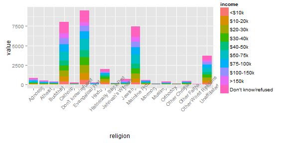

```r
ggplot(melt.raw, aes(religion, value)) + geom_bar(aes(fill = income), stat = "identity") +
    theme(axis.text.x = element_text(angle = 45))
```

### 종교별 소득 비율

```r
library(plyr)
melt.raw <- ddply(melt.raw, .(religion), mutate, freq_sum = sum(value))
head(melt.raw)
```

```
##   religion  income value freq_sum
## 1 Agnostic   <$10k    27      826
## 2 Agnostic $10-20k    34      826
## 3 Agnostic $20-30k    60      826
## 4 Agnostic $30-40k    81      826
## 5 Agnostic $40-50k    76      826
## 6 Agnostic $50-75k   137      826
```

```r
melt.freq <- ddply(melt.raw, .(religion, income), summarise, freq_percent = value/freq_sum)
head(melt.freq)
```

```
##   religion  income freq_percent
## 1 Agnostic   <$10k      0.03269
## 2 Agnostic $10-20k      0.04116
## 3 Agnostic $20-30k      0.07264
## 4 Agnostic $30-40k      0.09806
## 5 Agnostic $40-50k      0.09201
## 6 Agnostic $50-75k      0.16586
```

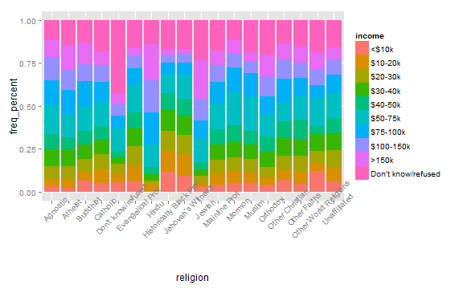

```r
ggplot(melt.freq, aes(religion, freq_percent)) + geom_bar(aes(fill = income),
    stat = "identity") + theme(axis.text.x = element_text(angle = 45))
```

## 3. `tapply`/ `aggregate`/ `by` Function

- R은 특정 데이터 집단에 함수를 적용하는 `tapply`,`by`,`aggregate`등의 함수를 제공함
- 이들의 원리는 **split-apply-comebine** 이라는 전략을 사용함
- 즉, 특정 기준에 따라 데이터를 나눠(**split**) 그룹화 한 후, 개별적으로 처리해(**apply**) 마지막에 남은 결과를 결합(**combine**)하는 효율적인 방식임

> **MapReduce개념과도 비슷함**

### Market price

- 서울시의 전통시장과 대형마트에서 생필품이 얼마나 판매되고 있는지를 조사한 자료임

```r
name.ENG <- c("P_SEQ", "M_SEQ", "M_NAME", "A_SEQ", "A_NAME", "A_UNIT", "A_PRICE",
    "P_YEAR_MONTH", "ADD_COL", "M_TYPE_CODE", "M_TYPE_NAME", "M_GU_CODE", "M_GU_NAME")
name.KOR <- c("일련번호", "시장/마트번호", "시장/마트이름", "품목번호", "품목이름",
    "실판매규격", "가격", "월-년도", "비고", "시장유형구분코드", "시장유형구분이름",
    "자치구 코드", "자치구이름")
name <- matrix(c(name.ENG, name.KOR), 13, 2)
name
```

```
##       [,1]           [,2]
##  [1,] "P_SEQ"        "일련번호"
##  [2,] "M_SEQ"        "시장/마트번호"
##  [3,] "M_NAME"       "시장/마트이름"
##  [4,] "A_SEQ"        "품목번호"
##  [5,] "A_NAME"       "품목이름"
##  [6,] "A_UNIT"       "실판매규격"
##  [7,] "A_PRICE"      "가격"
##  [8,] "P_YEAR_MONTH" "월-년도"
##  [9,] "ADD_COL"      "비고"
## [10,] "M_TYPE_CODE"  "시장유형구분코드"
## [11,] "M_TYPE_NAME"  "시장유형구분이름"
## [12,] "M_GU_CODE"    "자치구 코드"
## [13,] "M_GU_NAME"    "자치구이름"
```

```r
market_price <- read.csv("d:/SDSEDU/munging/requisites.csv", fileEncoding = "euc-kr")
head(market_price)
```

```
##    P_SEQ M_SEQ       M_NAME A_SEQ           A_NAME A_UNIT A_PRICE
## 1 319572   199 서울중앙시장   305 사과(부사, 300g)    1개    2500
## 2 319573   199 서울중앙시장   306   배(신고, 600g)    1개    3000
## 3 319574   199 서울중앙시장   307    배추(2.5~3kg)  1포기    5000
## 4 319575   199 서울중앙시장   308          무(1kg)    1개    1500
## 5 319576   199 서울중앙시장   309    양파(1.5kg망)    1망    2000
## 6 319577   199 서울중앙시장    23             상추   100g    1200
##   P_YEAR_MONTH ADD_COL M_TYPE_CODE M_TYPE_NAME M_GU_CODE M_GU_NAME
## 1       Jul-12  국내산           1    전통시장    140000      중구
## 2       Jul-12  국내산           1    전통시장    140000      중구
## 3       Jul-12  국내산           1    전통시장    140000      중구
## 4       Jul-12  국내산           1    전통시장    140000      중구
## 5       Jul-12  국내산           1    전통시장    140000      중구
## 6       Jul-12  국내산           1    전통시장    140000      중구
```

```r
summary(market_price)
```

```
##      P_SEQ            M_SEQ                   M_NAME         A_SEQ
##  Min.   :299094   Min.   :  1   2001아울렛 불광점:  48   Min.   : 13
##  1st Qu.:302232   1st Qu.: 49   경동시장         :  48   1st Qu.:134
##  Median :313531   Median : 94   고척근린시장     :  48   Median :266
##  Mean   :312873   Mean   :103   공릉 도깨비시장  :  48   Mean   :220
##  3rd Qu.:322914   3rd Qu.:145   광장시장         :  48   3rd Qu.:307
##  Max.   :324241   Max.   :222   구로시장         :  48   Max.   :317
##                                 (Other)          :4379
##                  A_NAME             A_UNIT        A_PRICE
##  오이(다다기)       : 264   1개        :1163   Min.   :    0
##  닭고기(육계)       : 254   1마리      : 391   1st Qu.: 1400
##  쇠고기(한우,불고기): 242   600g       : 386   Median : 2490
##  고등어(생물,국산)  : 237   10개       : 269   Mean   : 4274
##  달걀(왕란)         : 235   1포기      : 256   3rd Qu.: 4300
##  배(신고, 600g)     : 228   1마리(30cm): 135   Max.   :39000
##  (Other)            :3207   (Other)    :2067
##  P_YEAR_MONTH     ADD_COL      M_TYPE_CODE     M_TYPE_NAME
##  Jul-12:1567          : 689   Min.   :1.00   대형마트:2383
##  Jun-12:1533   국내산 : 257   1st Qu.:1.00   전통시장:2284
##  May-12:1567   국산   :  96   Median :2.00
##                제주   :  65   Mean   :1.51
##                무안   :  59   3rd Qu.:2.00
##                부산   :  43   Max.   :2.00
##                (Other):3458
##    M_GU_CODE         M_GU_NAME
##  Min.   :110000   관악구  : 240
##  1st Qu.:260000   영등포구: 240
##  Median :410000   강동구  : 192
##  Mean   :424495   강북구  : 192
##  3rd Qu.:560000   강서구  : 192
##  Max.   :740000   광진구  : 192
##                   (Other) :3419
```

### 3.1 `tapply` 사용 예

- `tapply(X, INDEX, FUN=NULL, ... , simplify=TRUE)`
  - `X` : 우리가 확인하고자 하는 가격
  - `INDEX` : factor형으로 구성된 list (data.frame은 list이기도 함)
  - `FUN` : 함수명을 입력함

```r
t.market <- tapply(market_price$A_PRICE, market_price[, c("M_TYPE_NAME", "A_NAME")],
    mean)
head(t.market)
```

```
##            A_NAME
## M_TYPE_NAME 고등어 고등어(30cm,국산) 고등어(냉동,국산) 고등어(냉동,수입산)
##    대형마트   1000              5335              2825                1500
##    전통시장     NA              2667              3525                1750
##            A_NAME
## M_TYPE_NAME 고등어(생물,국산) 고등어(생물,수입산) 냉동참조기(20cm,국산)
##    대형마트              4550                  NA                 824.7
##    전통시장              3269                1500                    NA
##            A_NAME
## M_TYPE_NAME 달걀 달걀(왕란) 달걀(특란) 닭고기 닭고기(육계) 닭고기(중간)
##    대형마트 2473       2614       2130   6573         7922         5580
##    전통시장 2500       2094       2225   6058         5466           NA
##            A_NAME
## M_TYPE_NAME 동태 돼지고기(삼겹살) 돼지고기(생삼겹살) 명태 명태(45cm,국산)
##    대형마트  990            13358              15045 1208               0
##    전통시장 4900            12759              11769 1500              NA
##            A_NAME
## M_TYPE_NAME 명태(45cm,수입산) 명태(냉동,수입산) 명태(러시아,냉동)
##    대형마트              2096              2385              2376
##    전통시장              2872              3370              2282
##            A_NAME
## M_TYPE_NAME 명태(생물,수입산)   무 무(1kg) 무(세척무) 무(세척무, 중)   배
##    대형마트             476.5 1616    1852       2156           1834 3961
##    전통시장            2352.9 1398    1415       1311             NA 2944
##            A_NAME
## M_TYPE_NAME 배(신고) 배(신고),중급(대) 배(신고, 600g) 배(중품)
##    대형마트     5997              3033           4375     3705
##    전통시장     3546                NA           3099     3111
##            A_NAME
## M_TYPE_NAME 배(중품),신고 배추 배추(2.5~3kg) 배추(국산) 배추(중간) 사과
##    대형마트          2187 2241          2470       2745       2273 2718
##    전통시장          3750 2471          2724         NA       2129 2651
##            A_NAME
## M_TYPE_NAME 사과(부사) 사과(부사),중급(중) 사과(부사, 300g) 사과(중품)
##    대형마트       2162                1650             3004       2534
##    전통시장       2459                  NA             2524       2438
##            A_NAME
## M_TYPE_NAME 삼겹살   상추 상추(100g) 생닭 쇠고기 쇠고기(등심)
##    대형마트     NA 1397.0     1155.5   NA  21720           NA
##    전통시장  12500  871.1      686.8 6000     NA        12467
```

[output cut: 13 more lines]

```
## M_TYPE_NAME 오징어(냉동,수입산) 오징어(생물,국산) 오징어(생물,수입산) 조기
##    대형마트                2120              2370                1680 6136
##    전통시장                  NA              2153                  NA 2771
##            A_NAME
## M_TYPE_NAME 조기(국산,냉동) 조기(국산,생물) 조기(냉동,국산)
##    대형마트            2884            3807            2104
##    전통시장            1517            2223            1840
##            A_NAME
## M_TYPE_NAME 조기(냉동,수입산) 조기(생물,국산) 조기(생물,수입산)
##    대형마트              4105            4165               990
##    전통시장              3426            1872                NA
##            A_NAME
## M_TYPE_NAME 조기(중국산,생물)  호박 호박(인큐베이터)
##    대형마트              1990 754.4            858.2
##    전통시장              4500 559.2            787.8
```

### 3.2 `by` 사용 예

```r
by(market_price$A_PRICE, market_price[, c("M_TYPE_NAME", "A_NAME")], function(x) {
    mean(x)
})
```

```
## M_TYPE_NAME: 대형마트
## A_NAME: 고등어
## [1] 1000
## --------------------------------------------------------
## M_TYPE_NAME: 전통시장
## A_NAME: 고등어
## [1] NA
## --------------------------------------------------------
## M_TYPE_NAME: 대형마트
## A_NAME: 고등어(30cm,국산)
## [1] 5335
## --------------------------------------------------------
## M_TYPE_NAME: 전통시장
## A_NAME: 고등어(30cm,국산)
## [1] 2667
## --------------------------------------------------------
## M_TYPE_NAME: 대형마트
## A_NAME: 고등어(냉동,국산)
## [1] 2825
## --------------------------------------------------------
## M_TYPE_NAME: 전통시장
## A_NAME: 고등어(냉동,국산)
## [1] 3525
## --------------------------------------------------------
## M_TYPE_NAME: 대형마트
## A_NAME: 고등어(냉동,수입산)
## [1] 1500
## --------------------------------------------------------
## M_TYPE_NAME: 전통시장
## A_NAME: 고등어(냉동,수입산)
## [1] 1750
## --------------------------------------------------------
## M_TYPE_NAME: 대형마트
## A_NAME: 고등어(생물,국산)
## [1] 4550
## --------------------------------------------------------
## M_TYPE_NAME: 전통시장
## A_NAME: 고등어(생물,국산)
## [1] 3269
## --------------------------------------------------------
```

[output cut: 528 more lines]

```
## M_TYPE_NAME: 대형마트
## A_NAME: 호박
## [1] 754.4
## --------------------------------------------------------
## M_TYPE_NAME: 전통시장
## A_NAME: 호박
## [1] 559.2
## --------------------------------------------------------
## M_TYPE_NAME: 대형마트
## A_NAME: 호박(인큐베이터)
## [1] 858.2
## --------------------------------------------------------
## M_TYPE_NAME: 전통시장
## A_NAME: 호박(인큐베이터)
## [1] 787.8
```

### 3.3 `aggregate` 사용 예

```r
aggregate(market_price$A_PRICE, market_price[, c("M_TYPE_NAME", "A_NAME")],
    mean)
```

```
##     M_TYPE_NAME                A_NAME       x
## 1      대형마트                고등어  1000.0
## 2      대형마트     고등어(30cm,국산)  5335.0
## 3      전통시장     고등어(30cm,국산)  2666.7
## 4      대형마트     고등어(냉동,국산)  2825.0
## 5      전통시장     고등어(냉동,국산)  3524.8
## 6      대형마트   고등어(냉동,수입산)  1500.0
## 7      전통시장   고등어(냉동,수입산)  1750.0
## 8      대형마트     고등어(생물,국산)  4550.5
## 9      전통시장     고등어(생물,국산)  3269.4
## 10     전통시장   고등어(생물,수입산)  1500.0
## 11     대형마트 냉동참조기(20cm,국산)   824.7
## 12     대형마트                  달걀  2472.5
## 13     전통시장                  달걀  2500.0
## 14     대형마트            달걀(왕란)  2614.3
```

[output cut: 116 more lines]

## 4. `plyr` Package

### 4.1 Basic frame of `plyr`

```
ddply(.data, .variables, .fun=NULL, ..., .progress="none", .drop = TRUE, .parallel = FALSE)
```

- **`.data`** : data.frame
- **`.variable`** : 쪼개는 기준값
  - 문자벡터 : `c("M_GU_NAME", "A_NAME")`
  - 숫자벡터 : c(5, 13)
  - 수식 (formula) : `~ M_GU_NAME + A_NAME`
  - 특별식 : `.(M_GU_NAME, N_NAME)`
- **`.fun`** : 함수명
- **…** : 함수명에 추가되는 인자
- **`.progress`** : 수행시간이 오래걸릴 경우를 대비, 진행상황을 표시
- **`.drop=TRUE`** : 현재 쪼개는 조건이 데이터에 있는 경우들만 계산하여 출력. FALSE면 모든 가능조건에 대해 출력
- **`.parallel`** : 머신의 멀티코어를 사용가능하게해주는 옵션

### 4.2 Example of `plyr`

```r
library(plyr)
head(ddply(market_price, .(A_NAME, M_TYPE_NAME), summarize, mean_price = mean(A_PRICE)))
```

```
##                A_NAME M_TYPE_NAME mean_price
## 1              고등어    대형마트       1000
## 2   고등어(30cm,국산)    대형마트       5335
## 3   고등어(30cm,국산)    전통시장       2667
## 4   고등어(냉동,국산)    대형마트       2825
## 5   고등어(냉동,국산)    전통시장       3525
## 6 고등어(냉동,수입산)    대형마트       1500
```

- `summarize` 은 그룹화된 data.frame을 요약한다는 의미임
- `summarize`이 외에 `transform`은 기존 data.frame에 새로운 열을 추가하거나 기존의 열을 다른 데이터로 채워넣을때 사용함
- 즉, `summarize` 함수는 `mean_price`에 대한 하나의 열만 변환하지만, `transform`은 열을 추가한 data.frame 조각 전체를 반환함

```r
library(plyr)
head(ddply(market_price, .(A_NAME, M_TYPE_NAME), transform, mean_price = mean(A_PRICE)))
```

```
##    P_SEQ M_SEQ            M_NAME A_SEQ            A_NAME       A_UNIT
## 1 301107    22   이마트 여의도점    13            고등어  1마리(30cm)
## 2 322354    74   이마트 왕십리점   316 고등어(30cm,국산)  1마리(30cm)
## 3 323250    56        롯데백화점   316 고등어(30cm,국산)        1마리
## 4 323378    16 현대백화점 미아점   316 고등어(30cm,국산)        1마리
## 5 323442    15     이마트 미아점   316 고등어(30cm,국산) 1마리 (30cm)
## 6 313052    16 현대백화점 미아점   316 고등어(30cm,국산)        1마리
##   A_PRICE P_YEAR_MONTH    ADD_COL M_TYPE_CODE M_TYPE_NAME M_GU_CODE
## 1    1000       May-12     작은것           2    대형마트    560000
## 2    2800       Jul-12 2마리 5600           2    대형마트    200000
## 3    7000       Jul-12     국내산           2    대형마트    140000
## 4    5000       Jul-12                      2    대형마트    290000
## 5    2800       Jul-12                      2    대형마트    290000
## 6    6000       Jun-12                      2    대형마트    290000
##   M_GU_NAME mean_price
## 1  영등포구       1000
## 2    성동구       5335
## 3      중구       5335
## 4    성북구       5335
## 5    성북구       5335
## 6    성북구       5335
```

## 5. `data.table` Package

### 5.1 Basic frame of `data.table`

```
dt[i,j,mult={'first','last','all'},nomatch={0,NA},roll={FALSE,TRUE},by='colname']
```

- **`i,j`** : i에는 행을 선택하는 문법, j에는 열을 선택하는 문법이 들어감
- **`mult`** : 'JOIN'연산 시, 키매칭의 처음, 마지막, 모두를 리턴하는 옵션
- **`nomatch`** : 'OUTER JOIN'을 사용할 때 주로 정해주는 옵션으로 매칭되지 않을 경우 리턴될 값을 명시
- **`roll`** : 시계열 데이터에 대한 'rolling join'을 하게될 때 주로 사용함

### 5.2 `data.table` vs. `data.frame`

- **`data.table`을 사용한 경우**

```r
library(data.table)
market_price.dt <- data.table(market_price)
market_price.dt[2, list(M_NAME)]
```

```
##          M_NAME
## 1: 서울중앙시장
```

- **`data.frame`을 사용한 경우**

```r
market_price[2, "M_NAME", drop = F]
```

```
##         M_NAME
## 2 서울중앙시장
```

```r
class(market_price.dt[2, list(M_NAME)])
```

```
## [1] "data.table" "data.frame"
```

```r
class(market_price[2, "M_NAME", drop = F])
```

```
## [1] "data.frame"
```

```r
class(market_price[2, "M_NAME", drop = T])
```

```
## [1] "factor"
```

- `data.frame`은 한 열을 리턴할 때 벡터로 리턴하고, 두 개 이상의 열을 리턴할 때 data.frame으로 리턴하는 특이한 방식을 사용하기 때문에 `drop=F`를 사용해주어야 한다.
- `data.table`은 리스트로 열 이름을 받게하고 모든 경우에 `data.table`로 리턴한다.

```r
market_price.dt[, list(avg = mean(A_PRICE)), by = list(M_TYPE_NAME, A_NAME)]
```

```
##      M_TYPE_NAME              A_NAME  avg
##   1:    전통시장    사과(부사, 300g) 2524
##   2:    전통시장      배(신고, 600g) 3099
##   3:    전통시장       배추(2.5~3kg) 2724
##   4:    전통시장             무(1kg) 1415
##   5:    전통시장       양파(1.5kg망) 2209
##  ---
## 126:    전통시장              오징어 1660
## 127:    대형마트 고등어(냉동,수입산) 1500
## 128:    대형마트              고등어 1000
## 129:    전통시장 고등어(생물,수입산) 1500
## 130:    대형마트 오징어(생물,수입산) 1680
```

- `list`로 묶인 변수들에 의해 **GROUP BY**된 각각의 `data.table`에 `avg`열을 입력해 `A_PRICE`의 평균값을 넣음

### 5.3 `sqldf`

```r
library(sqldf)
sqldf("select M_TYPE_NAME, A_NAME, avg(A_PRICE) as avg from market_price group by M_TYPE_NAME,A_NAME limit 10")
```

```
##    M_TYPE_NAME                A_NAME    avg
## 1     대형마트                고등어 1000.0
## 2     대형마트     고등어(30cm,국산) 5335.0
## 3     대형마트     고등어(냉동,국산) 2825.0
## 4     대형마트   고등어(냉동,수입산) 1500.0
## 5     대형마트     고등어(생물,국산) 4550.5
## 6     대형마트 냉동참조기(20cm,국산)  824.7
## 7     대형마트                  달걀 2472.5
## 8     대형마트            달걀(왕란) 2614.3
## 9     대형마트            달걀(특란) 2130.0
## 10    대형마트                닭고기 6573.5
```

- **sqldf** 는 data.frame을 흡사 데이터베이스의 테이블 처럼 여기며, SQL문으로 조작할 수 있는 인터페이스를 제공함

### 5.4 `ddply` vs. `data.table` vs. `sqldf`

- **`ddply`**

```r
system.time(ddply(market_price, .(M_TYPE_NAME, A_NAME), summarise, avg = mean(A_PRICE)))
```

```
##    user  system elapsed
##    0.08    0.00    0.08
```

- **`data.table`**

```r
system.time(market_price.dt[, list(avg = mean(A_PRICE)), by = list(M_TYPE_NAME,
    A_NAME)])
```

```
##    user  system elapsed
##    0.02    0.00    0.02
```

- **`sqldf`**

```r
system.time(sqldf("select M_TYPE_NAME,A_NAME, avg(A_PRICE) as avg from market_price group by M_TYPE_NAME, A_NAME"))
```

```
##    user  system elapsed
##    0.03    0.00    0.05
```

- `data.table` >> `sqldf` >> `plyr` 순으로 속도가 빠른것을 알 수 있음

## 6. Reson of Munging

[output not shown]

- 원데이터로는 표현하기 힘든 분류된 시각화를 수행할 수 있음

> 본 자료는 'R로 하는 데이터 시각화 (전희원 지음)을 참고 및 인용하여 작성한 것임

> 관련 참고사이트 https://github.com/haven-jeon/R_based_visualization